# Part 2 - Prosper Loan Dataset Explanatory Project

#### by Babatunde Akeredolu

### Investigation Overview

This is an explanatory analysis of Prosper Loan dataset. In this analysis, I look at the variables that were best in predicting a loan's outcome status and also the value of the loan.

### Dataset Overview

The data set contains 113,937 loans with 81 variables on each loan, including loan amount, borrower rate (or interest rate), current loan status, borrower income, and many others.

### Distribution of ProsperScores

Majority of the loan's risk scores are average with 4, 5 and 6 being the risk scores associated with most loans. However, more than half of the loans are on the positive side of the risk scores.

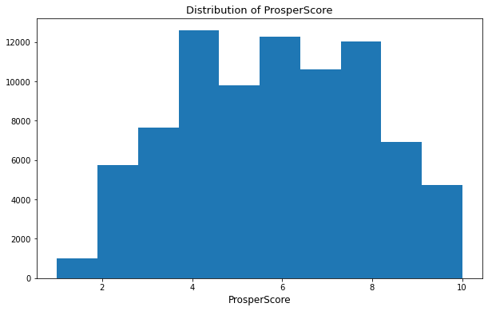

### Distribution of OnTimeProsperPayments

Most of the borrowers are on time payers as the number of on time payments are high, this can be seen in the distribution plot as most of the data are concentrated on the far left of the axis.

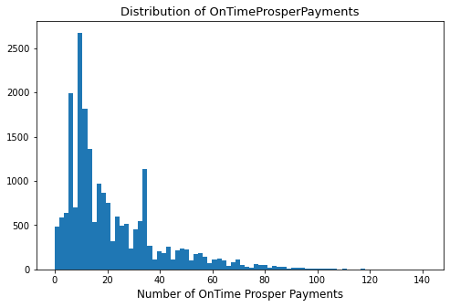

### TotalProsperLoans & OnTimeProsperPayments

TotalProsperLoans and OnTimeProsperPayments are positively and highly correlated, the higher the OnTimeProsperPayments, the higher the number of loans that were taken.

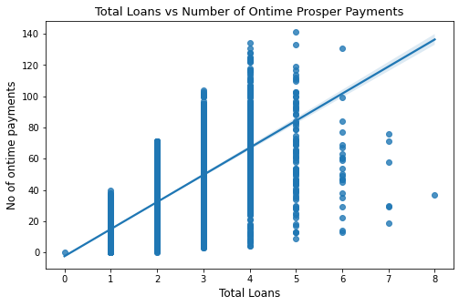

### ProsperScore vs LoanStatus

ProsperScores are high for loans that are completed. For loans that are due, the ProsperScores are quite low.

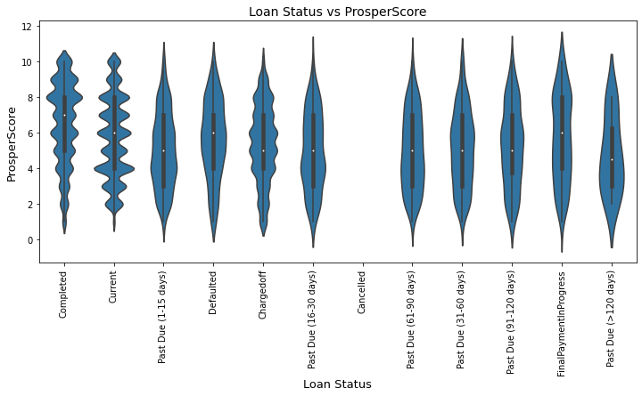

### IncomeRange vs LoanOriginalAmount

With few exceptions (Not employed and zero income earners), as income of borrowers increases, the higher the amount of loans they take.

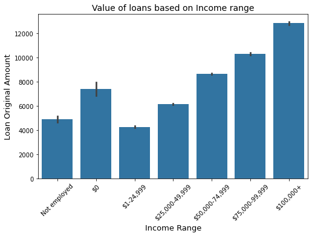

### IncomeRange vs LoanOriginalAmount vs Term

The three variables - IncomeRange, LoanOriginalAmount and Term - have quite an interesting relationships, as Loan increases, Income Range increases as well as the term of the loan, this means that high income earners take high amount of loans with longer period of time. The only exception is for the first two categories (Not employed and zero income earners).

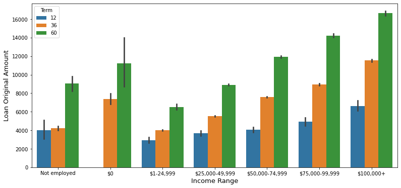